# Loan_Project_Python

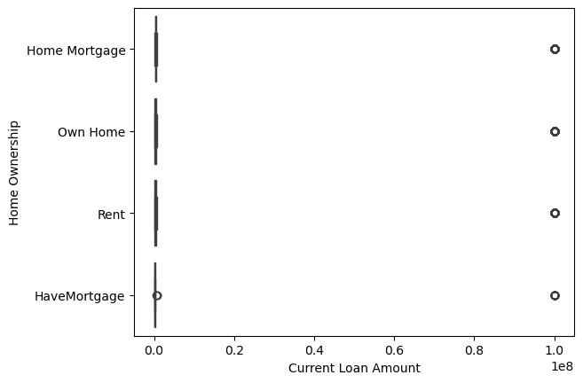

```python
sns.boxplot(data=df , x='Current Loan Amount' , y ='Home Ownership')
```

17.How does the annual income vary with the years in the current job?

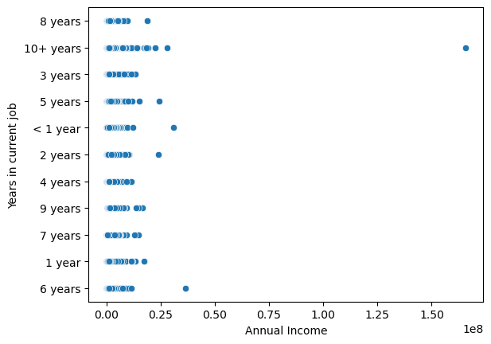

```python
sns.scatterplot(data=df , x='Annual Income' , y='Years in current job')
```

18.Is there a correlation between the current loan amount and the monthly debt?

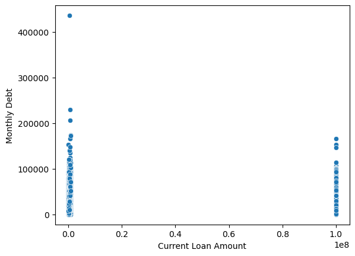

```python
sns.scatterplot(data=df , x='Current Loan Amount' , y ='Monthly Debt')
```

19.What is the average monthly debt for each home ownership type?

```python
df.groupby('Home Ownership')['Monthly Debt'].mean()
```

```
Home Ownership
HaveMortgage     18541.776822
Home Mortgage    21072.059467
Own Home         17060.082101
Rent             15796.777284
Name: Monthly Debt, dtype: float64
```

20.How does the credit score vary with the number of open accounts?

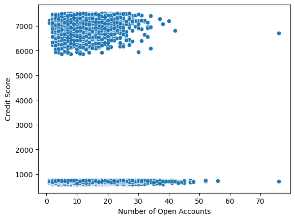

```python
sns.scatterplot(data=df , x='Number of Open Accounts', y='Credit Score')
```

21.What is the distribution of credit scores across different loan statuses?

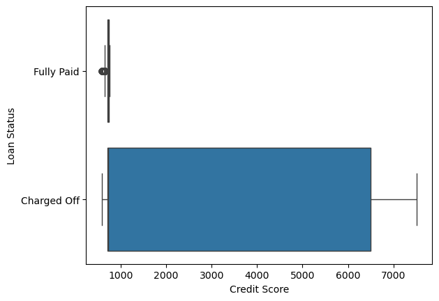

```python
sns.boxplot(data=df , x='Credit Score' , y='Loan Status')
```

22.Is there a correlation between the current loan amount and the years of credit history?

```python
df[['Years of Credit History','Current Loan Amount']].corr()
```

|  | Years of Credit History | Current Loan Amount |
| --- | --- | --- |
| Years of Credit History | 1.000000 | 0.019282 |
| Current Loan Amount | 0.019282 | 1.000000 |

23.How does the monthly debt vary with the number of credit problems?

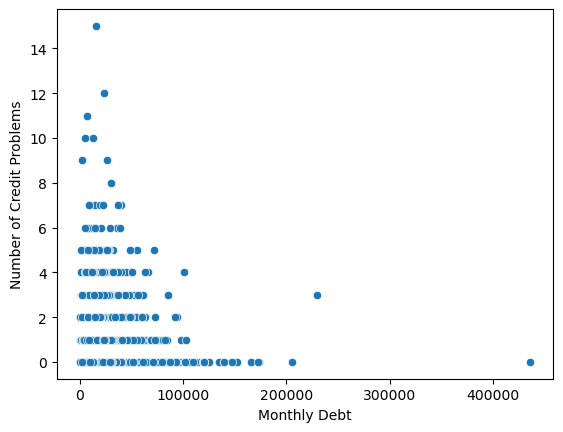

```python
sns.scatterplot(data=df , x='Monthly Debt' , y='Number of Credit Problems')
```

24.What is the average current loan amount for each purpose of loan?

```python
df.groupby('Purpose')['Current Loan Amount'].mean()
```

```
Purpose
Business Loan           7.837789e+06
Buy House               1.106036e+07
Buy a Car               1.414682e+07
Debt Consolidation      1.180683e+07
Educational Expenses    1.428536e+07
Home Improvements       1.252117e+07
Medical Bills           1.179902e+07
Other                   1.253627e+07
Take a Trip             1.111667e+07
major_purchase          1.298956e+07
moving                  1.350072e+07
other                   1.059243e+07
renewable_energy        1.975534e+05
small_business          9.484232e+06
vacation                7.058680e+06
wedding                 1.760299e+07
Name: Current Loan Amount, dtype: float64
```

25.How does the credit score vary with the current credit balance?

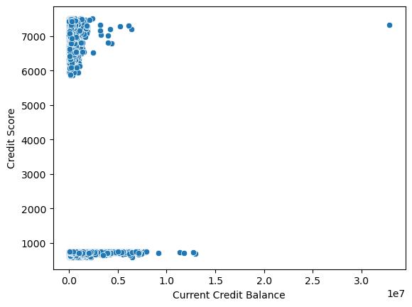

```python
sns.scatterplot(data=df , x='Current Credit Balance' , y='Credit Score')
```

26.Is there a correlation between the annual income and the current credit balance?

[output not shown]

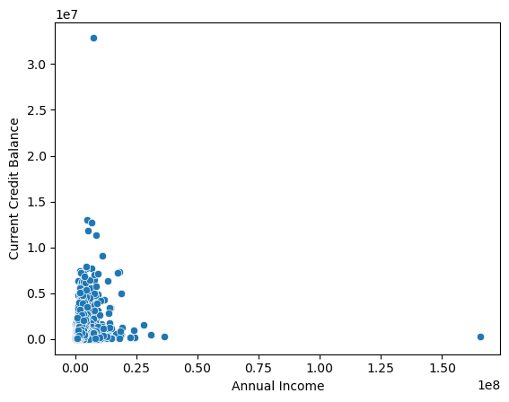

```python
sns.scatterplot(data=df , x='Annual Income' , y='Current Credit Balance').corr()
```

```python
df[['Current Credit Balance','Annual Income']].corr()
```

|  | Current Credit Balance | Annual Income |
| --- | --- | --- |
| Current Credit Balance | 1.00000 | 0.31234 |
| Annual Income | 0.31234 | 1.00000 |

27.What is the distribution of annual income across different terms (short-term vs. long-term)?

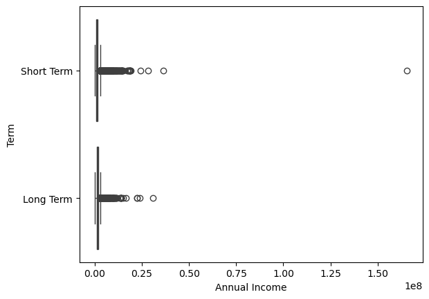

```python
sns.boxplot(data=df , x='Annual Income', y='Term')
```

28.How does the credit score vary with the number of credit problems?

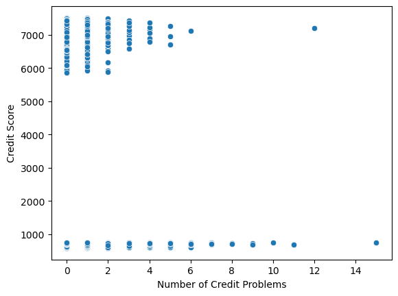

```python
sns.scatterplot(data=df , x='Number of Credit Problems' , y='Credit Score')
```

29.Is there a correlation between the current loan amount and the number of credit problems?

```python
df[['Number of Credit Problems','Current Loan Amount']].corr()
```

|  | Number of Credit Problems | Current Loan Amount |
| --- | --- | --- |
| Number of Credit Problems | 1.000000 | -0.002795 |
| Current Loan Amount | -0.002795 | 1.000000 |

30.What is the relationship between the number of open accounts and the years of credit history?

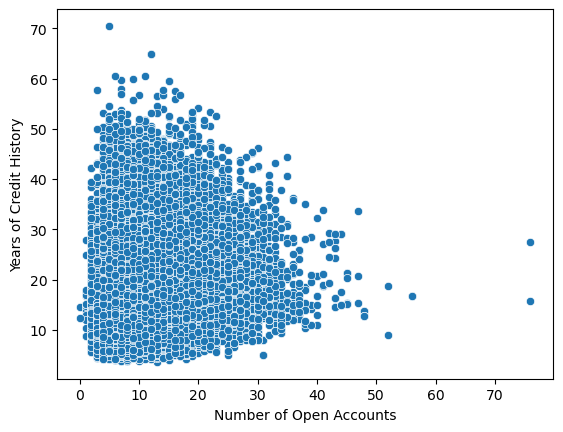

```python
sns.scatterplot(data=df , x='Number of Open Accounts' , y='Years of Credit History')
```